# PCA analysis

Annie Bryant

5/8/2022

## Step 3

AROMA + 2P

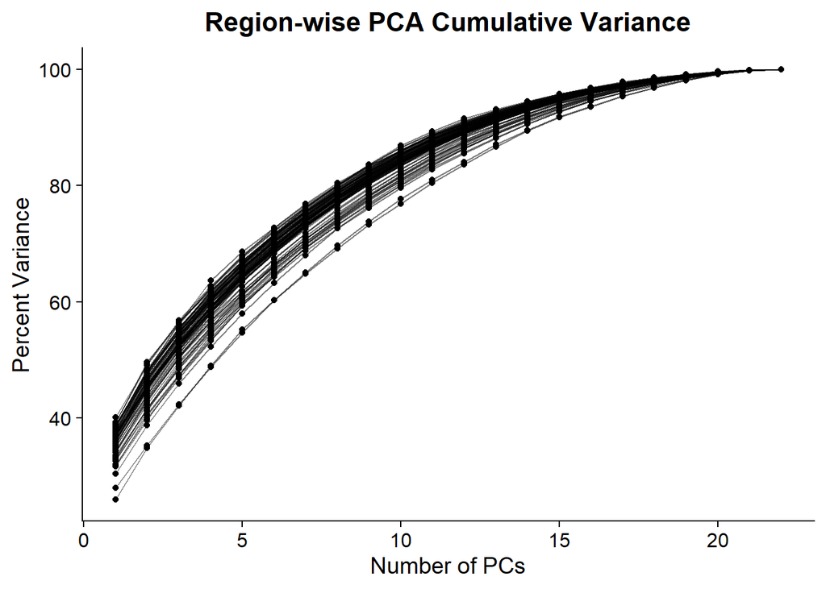

## Step 4

AROMA + 2P

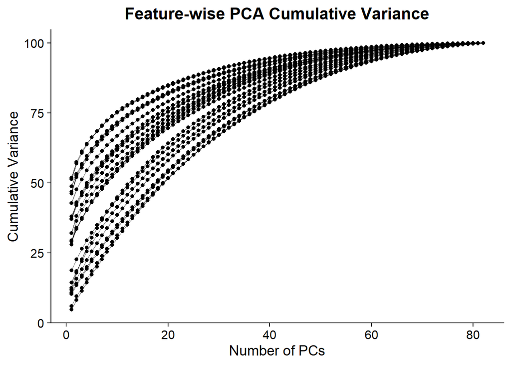

Let’s see where balanced accuracy starts to hit 100% across the 22 features:

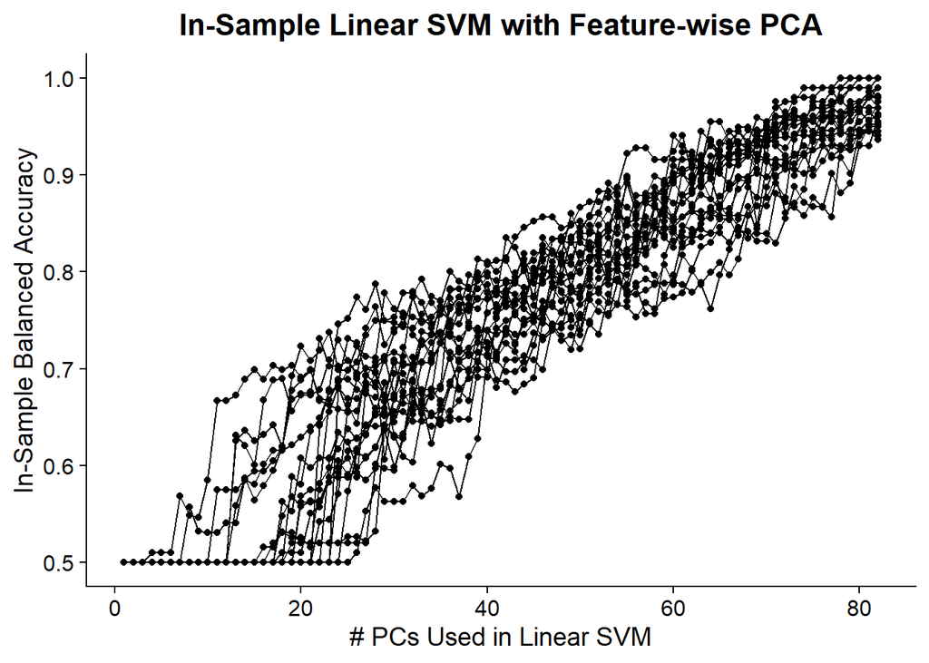

For the sake of comparison, I’ll do this for inverse probability weighting as well:

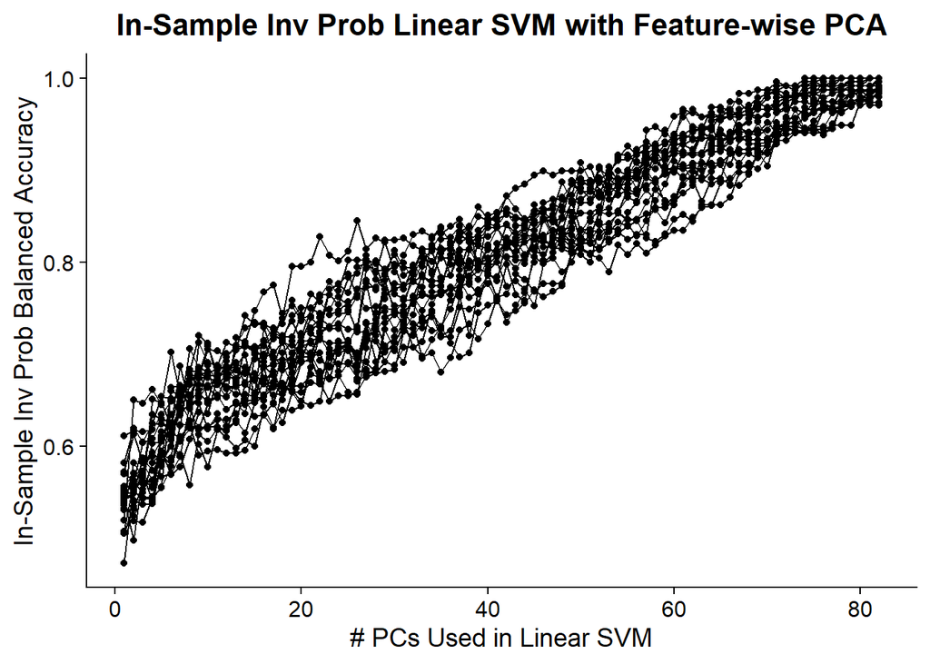

We can do the same with cross-validation and inverse probability weighting:

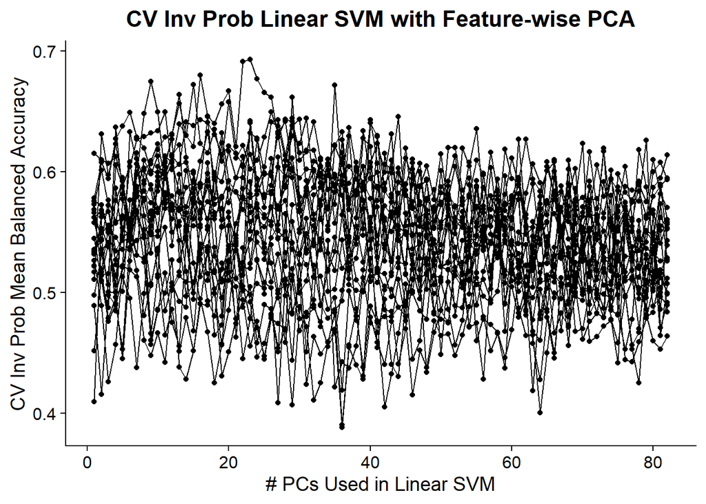

And with SMOTE

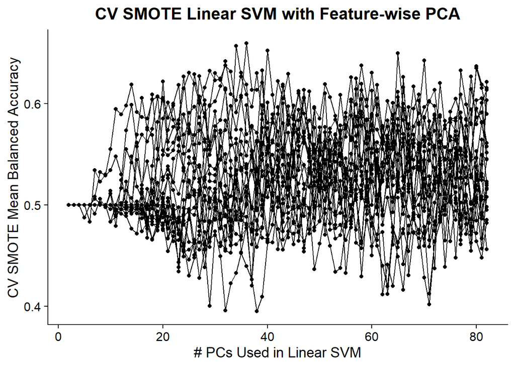

Combine all into one plot

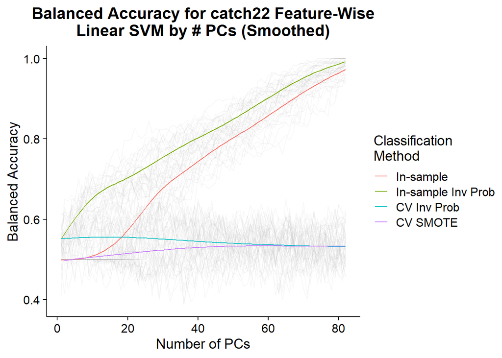

## Step 5

AROMA + 2P

Cumulative analysis

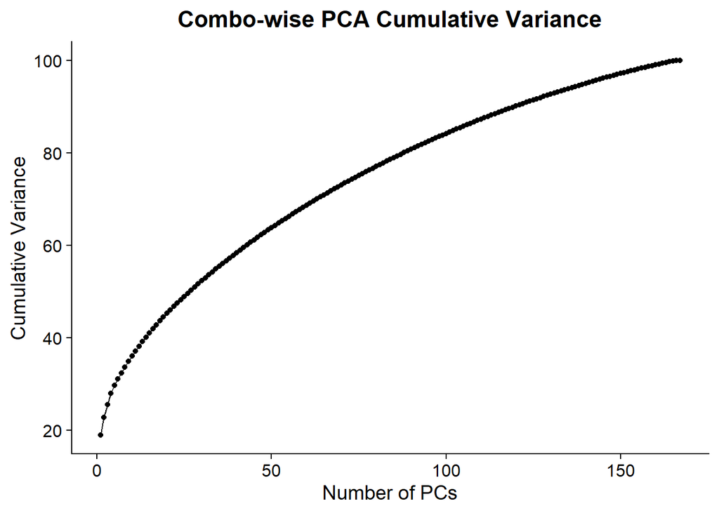

Run in-sample linear SVM for each number of PCs from 1 to 167

Run in-sample linear SVM with inverse probability weighting for each number of PCs from 1-167

Run linear 10-fold SVM for each number of PCs from 1-167

Run linear 10-fold CV SVM for each number of PCs from 1 to 167 with inverse probability weighting

Run linear 10-fold CV SVM for each number of PCs from 1 to 167 with SMOTE

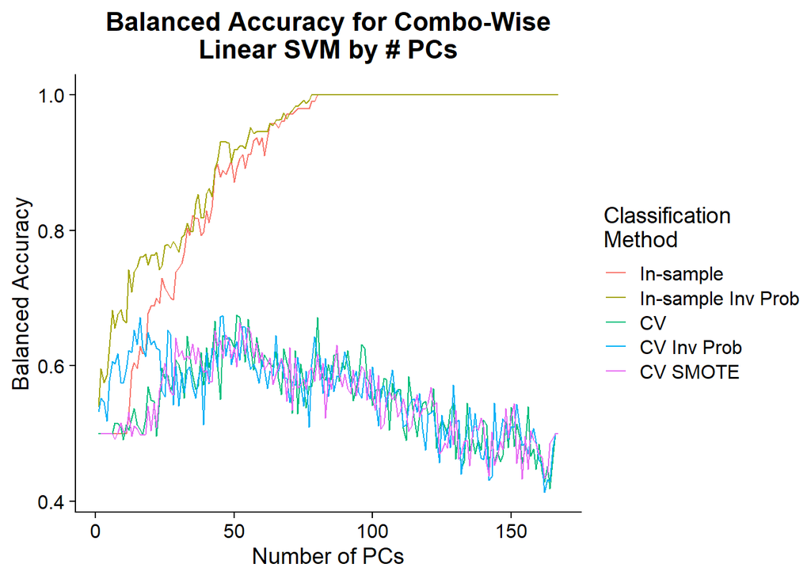

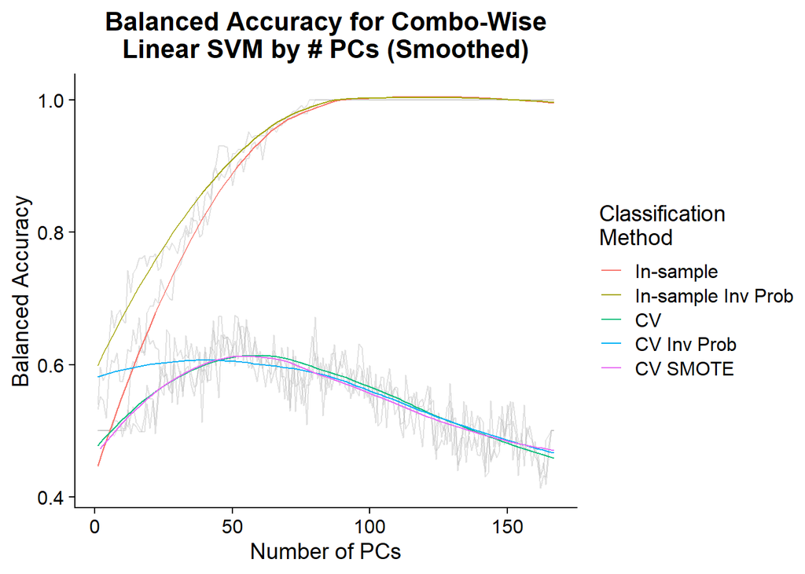